# My Fargate Startup is Slow

Dror Speiser

Ljubljana 2025

*Coworker* built amazing docker image - **2700 MB**

I need to deploy to **AWS Fargate - startup is 55 seconds** !!!

# Wait what's AWS Fargate?

- Serverless **docker containers**
- No server setup or management required
- Auto-handles scaling and infrastructure

# Ideas for faster startup?

Build:

- Remove unnecessary files, e.g. caches, node_modules, use multistage builds
- Use smaller base, e.g. alpine instead of ubuntu
- Organize layers to have more cache hits

Post build:

- deduplicate files - turn copies into links
- use zst instead of gzip
- reorder files in layers' tars
- redistribute files across layers

# What's in a docker image file?

A tar file by any other name would extract as sweet

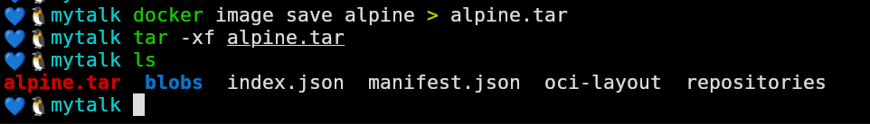

manifest.json points to layers' tar files

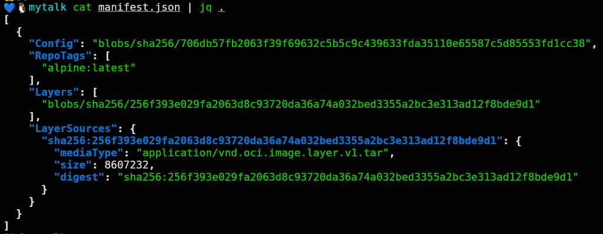

We can extract a layer

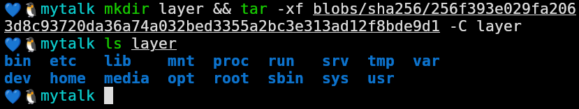

## what we learned:

# Docker images = tars in tars

so we can distribute our image files across layers however we want

# How does Fargate download our image?

We'll look for a blog post by Amazon themselves

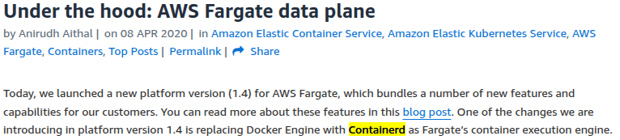

We read the **code of containerd** and learn

## 1. Layers download in parallel

## 2. When ready: extract, in sequence

# How **fast** does Fargate download our image?

We'll do an experiment - science!

1. Create our **own docker registry** that logs layer pull times
2. Run it on EC2, push an image
3. Create a Fargate task that uses our registry and image
4. Analyze logs